# Procedurally generated worlds using Pandas and Numpy

I'm a big fan of rouge-like games and RPGs. I'm also a big fan of data science tools for Python. This is my attempt to have it all. Because these notebooks call from modules used in the live game, I also use them for dev / testing. If something is crashing in the game I can simulate it here to see what is wrong and test out new features before dropping them in the production code.

In the live game there are three stages of creation:

- The age of **elements** - building terrain
- The age of **mortals** - adding cities and nations
- The age of **conflict** - random events that shift the relationships between nations, towns and people.

Currently only 1 and 2 are shown here.

```python
import pandas as pd
import numpy as np
import pickle

import altair as alt

#importing local libraries for drawings (because they clutter)
#I'm mapping to the actual files in the repo so that I can also use this to troubleshoot
import sys
sys.path.append('../')
sys.path.append('../../')
from lib.builders import world as w, landscape as l
from lib.builders import people,towns,nations,culture as c

import lib.drawMaps as draw
```

There are default parameters that I've chosen as the best fit for creating a *'believable'* world. You can experiment with those variables by editing them here. They won't affect the production parameters.

```python
l.default_params
```

```
{'grid': [40, 40], 'N_loc': 0, 'N_std': 1}
```

```python
landscape = l.Landscape()
landscape
```

```
<lib.builders.landscape.Landscape at 0x7f8aefcadda0>
```

I'm going to use the `landscape` over and over to specify the world's parameters. Some of the parameters are set by the user and some of them are hard cast.

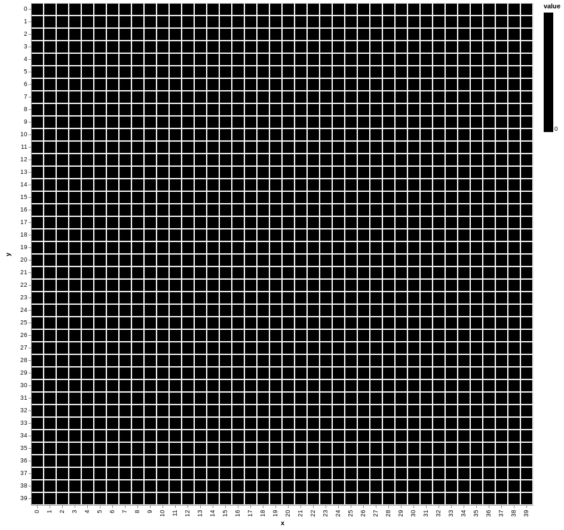

```python
world = w.World(landscape)
draw.drawTerrainHeight(world.grid_elevation)
```

# in the beginning, the world was void and without form.

Starting with a grid with nothing on it. No elevation, no terrain. All of this will be generated procedurally.

You can see here that the terrain is shifted on a random-normal distribution to make it look *uneven*. Making it randomly doesn't make it look *real* so I'm going to have to be smarter about the rules that raise and lower terrain in order to make them look like mountains.

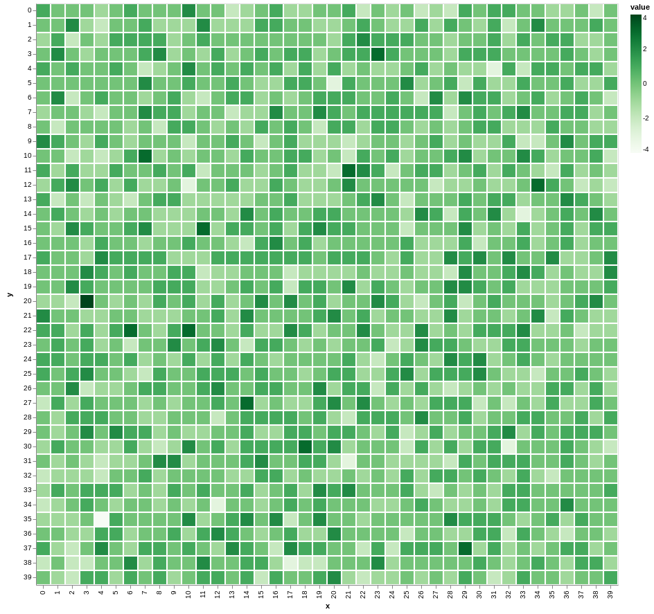

```python
world.shift_terrain()
draw.drawTerrainHeight(world.grid_elevation)
```

Just random terrain shifting won't make anything like real terrain types.

# Mountains formed

Using Np.pad to build a pyramid, I'm making something that looks much more like a mountain. This is just a single mountain.

```python
world.getMountain()
```

|  | 0 | 1 | 2 |
| --- | --- | --- | --- |
| 0 | 1 | 1 | 1 |
| 1 | 1 | 2 | 1 |
| 2 | 1 | 1 | 1 |

This is great, but I need to place the mountain on a random place on the terrain. Currently just drop the edges of the mountain if they go off the grid. I might wrap them around later. **Note** height needs to be odd in order to draw symmetrically.

```python
coord = world.get_random_chord()
m = world.getMountain(height=5)
print("Mountain Placed: ", coord)

mdf = world.reindexMountain(coord,m)
mdf
```

```
Mountain Placed:  [2 9]
```

|  | 5 | 6 | 7 | 8 | 9 | 10 | 11 | 12 | 13 |
| --- | --- | --- | --- | --- | --- | --- | --- | --- | --- |
| -2 | 1 | 1 | 1 | 1 | 1 | 1 | 1 | 1 | 1 |
| -1 | 1 | 2 | 2 | 2 | 2 | 2 | 2 | 2 | 1 |
| 0 | 1 | 2 | 3 | 3 | 3 | 3 | 3 | 2 | 1 |
| 1 | 1 | 2 | 3 | 4 | 4 | 4 | 3 | 2 | 1 |
| 2 | 1 | 2 | 3 | 4 | 5 | 4 | 3 | 2 | 1 |
| 3 | 1 | 2 | 3 | 4 | 4 | 4 | 3 | 2 | 1 |
| 4 | 1 | 2 | 3 | 3 | 3 | 3 | 3 | 2 | 1 |
| 5 | 1 | 2 | 2 | 2 | 2 | 2 | 2 | 2 | 1 |
| 6 | 1 | 1 | 1 | 1 | 1 | 1 | 1 | 1 | 1 |

This makes a much more *natural* looking mountain.

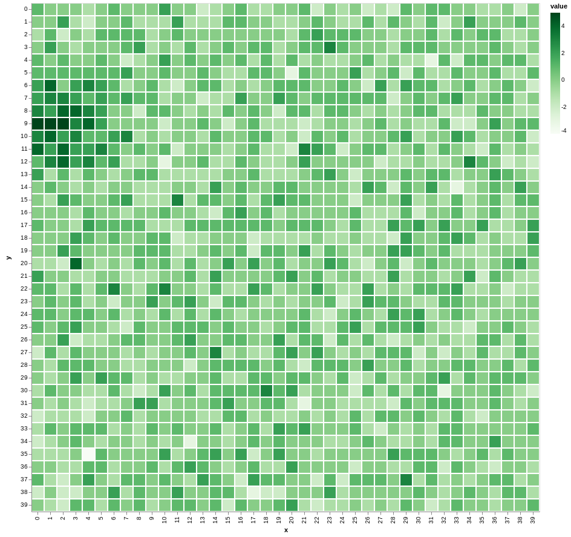

```python
world.add_mountain(mdf)
draw.drawTerrainHeight(world.grid_elevation)
```

It's a good looking mountain, but I need mountain ranges not dots. In order to drag mountains on the board I'll need to create a brownian motion function to drop a mountain and then move.

```python
world.brownian_land()
```

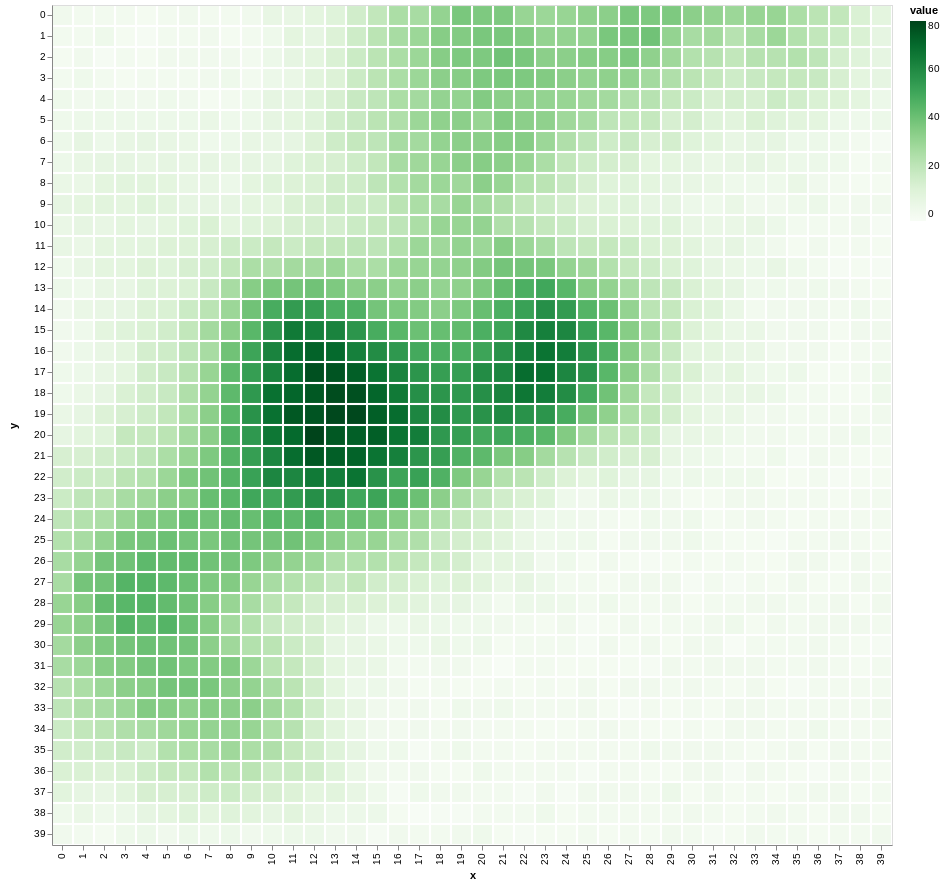

```python
draw.drawTerrainHeight(world.grid_elevation)
```

Now that's starting to look like land. The shapes come out really map-like. Compute time is lower than my previous version as well. Only drawing the Altair viz takes time.

## Oceans

If the oceans were to come in at `height == 0` then you can assume that lower terrain is *under water*

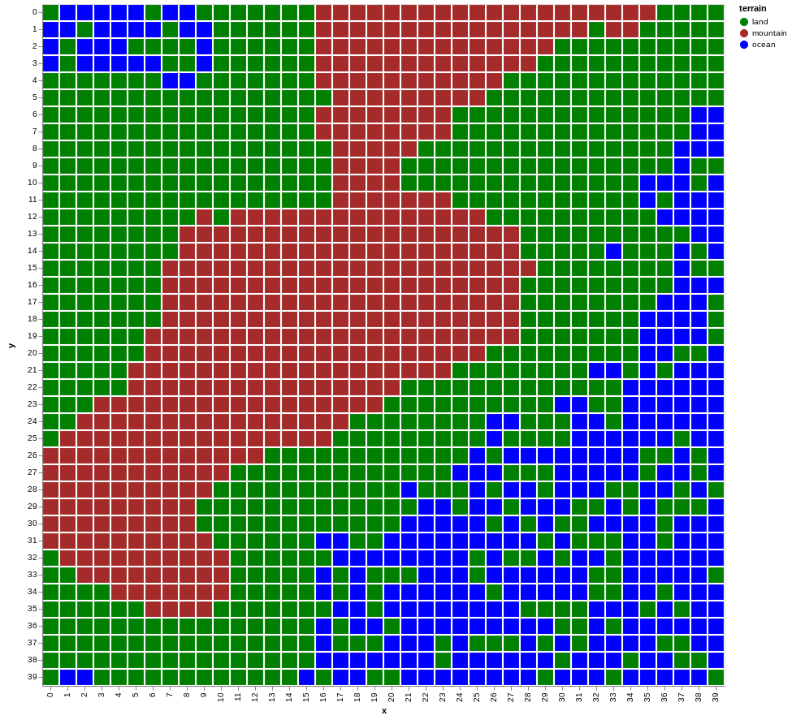

```python
draw.drawTerrainTypes(world.grid_elevation,world.landscape)
```

### Rainfall

Rainfall makes terrain different. Wet areas become forests. Dry areas become deserts.

```python
world.brownian_rainfall()
```

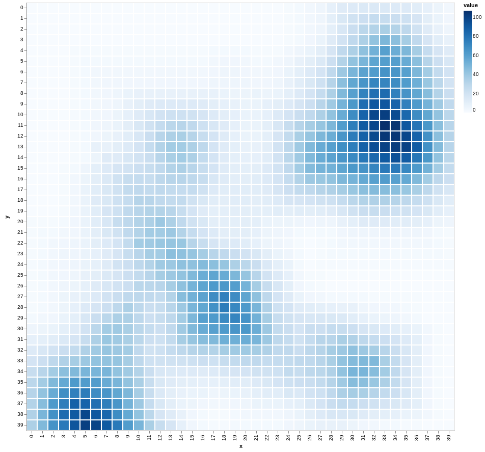

```python
draw.drawRainFall(world.grid_rainfall)
```

### Build core game features dataframe

This function builds the df_features that will be used later in the actual game. This way you can quickly search and filter the world to find things.

```python
world.build_df_features()
```

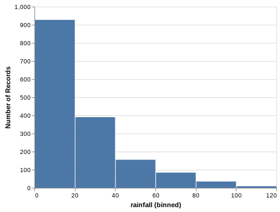

```python
alt.Chart(world.df_features).mark_bar().encode(
    alt.X("rainfall", bin=True),
    y='count()',
)
```

The amount of rainfal in the world determines if the area will become a forest or a desert. This can be set from the `landscape` parameters.

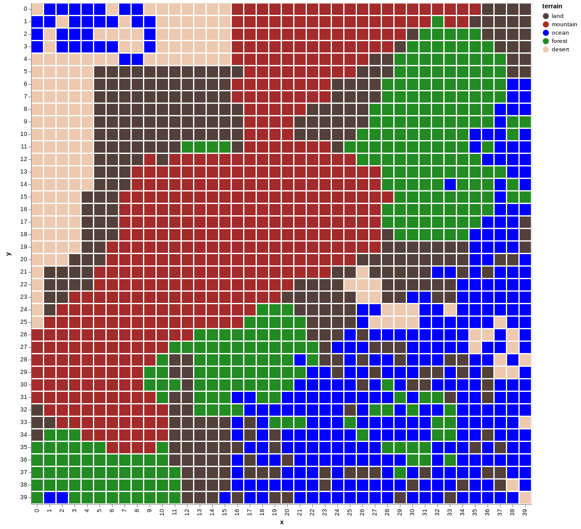

```python
world.df_features['terrain'] = world.df_features.apply(lambda x: w.set_ecology(x,landscape),axis =1 )
draw.drawterrainadvanced(world.df_features)
```

# The age of the ancients

The terrain and all of the natural features are formed in the first age. Mountains, rivers, lakes and forests. Once the land has settled, the first cities appear.

Culture settings come from the user input, there are defaults for everything. Once specified the `.culture` placeholder can be replaced. It should not be used until this point.

```python
c
```

```
<module 'lib.builders.culture' from '../lib/builders/culture.py'>
```

```python
# the path to the `datasets` folder is different when launched in the Notebook.
culture = c.Culture(paths='notebooks')
world.culture = culture
world.culture.eons
```

```
10
```

## People

A `Person` is a required parameter for many things like `towns`, `nations` and `buildings`

A person requires a `culture` to specify how the names will be generated. As a default the person is a `peon` and exists nowhere (`None`). Optional parameters allow the person to be created with a `role` and a `location`. `Location` can be a `town`, `building` or a `key` where the person can be found.

```python
people.Person(world.culture,location=world.get_random_chord())
```

```
Seklipak the peon
```

## Towns

the `__init__` method of a city takes a founding age and a location (which can be generated randomly via `World.get_random_chord`). The init method automatically generates a name. The default nation is the name of the town.

```python
new_town = towns.Town(world.get_random_chord(),1,culture,people)
new_town
```

```
town of Godhaven: population: 1 location: [3,22] founded 1
```

```python
new_town.speaker
```

```
Anapeltik the Speaker of Godhaven
```

## The age of civilization

Cities grow for a set number of aeons. During each eon

- n new villages are born
- each village has g% chance to grow

The cities are randomly placed (not in the ocean)

```python
all_towns = towns.build_towns(world,people)
world.towns = all_towns
[(str(p),p.population) for p in all_towns]
```

```
[('town of Lilyvale: population: 5 location: [1,15] founded 0',
  [Eliscim the Speaker of Lilyvale,
   Feflat the peon,
   Pikrackut the peon,
   Chistus the peon,
   Quarraf the peon]),
 ('town of Starblade: population: 6 location: [31,13] founded 1',
  [Shodrel the Speaker of Starblade,
   Dralindive the peon,
   Frakillis the peon,
   Tibbnan the peon,
   Xiflive the peon,
   Roldnan the peon]),
 ('town of Ratgarden: population: 5 location: [14,5] founded 1',
  [Dronnag the Speaker of Ratgarden,
   Zhafillek the peon,
   Ontend the peon,
   Hitoldunt the peon,
   Tockrane the peon]),
 ('town of Snaketown: population: 5 location: [20,9] founded 2',
  [Kiscunt the Speaker of Snaketown,
   Domendadle the peon,
   Mitoldai the peon,
   Krabraf the peon,
   Baklenton the peon]),
 ('town of Tearfellow: population: 3 location: [8,18] founded 3',
  [Bollai the Speaker of Tearfellow, Fifaddart the peon, Orkillale the peon]),
 ('town of Camcrawl: population: 4 location: [24,9] founded 3',
  [Ekoldelle the Speaker of Camcrawl,
   Stukrof the peon,
   Hicinnal the peon,
   Mospor the peon]),
 ('town of Snakejaw: population: 3 location: [28,13] founded 4',
  [Miglam the Speaker of Snakejaw, Fiwildud the peon, Kravallorg the peon]),
 ('town of Waterhollow: population: 4 location: [9,8] founded 6',
  [Shonoddoth the Speaker of Waterhollow,
   Adawildart the peon,
   Elibrunt the peon,
   Merpent the peon]),
 ('town of Doomtown: population: 3 location: [29,21] founded 6',
  [Thostif the Speaker of Doomtown, Hepeltath the peon, Pabbab the peon]),
 ('town of Ravenmore: population: 2 location: [28,30] founded 8',
  [Daspac the Speaker of Ravenmore, Quowath the peon]),
 ('town of Artfold: population: 2 location: [29,23] founded 8',
  [Theldrort the Speaker of Artfold, Eremsea the peon]),
 ('town of Artjaw: population: 2 location: [32,1] founded 9',
  [Asassorg the Speaker of Artjaw, Truhorkottle the peon]),
 ('town of Ratblade: population: 1 location: [5,33] founded 9',
  [Hekillus the Speaker of Ratblade]),
 ('town of Solhail: population: 1 location: [6,16] founded 9',
  [Nelandar the Speaker of Solhail])]
```

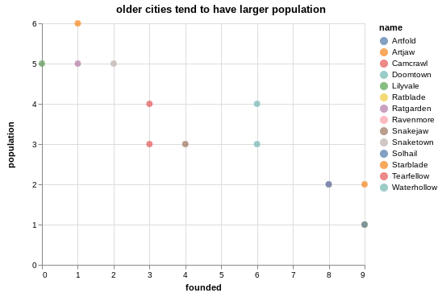

```python
def population_age(towns):
    df = pd.DataFrame(index=range(len(all_towns)))
    df['name'] = [t.name for t in all_towns]
    df['population'] = [t.pop for t in all_towns]
    df['founded'] = [t.founded for t in all_towns]
    return df

alt.Chart(population_age(towns),title="older cities tend to have larger population").mark_circle(size=60).encode(
    y='population',
    x='founded',
    color='name',
    tooltip=['name']
)
```

When the character arrives in said town, all of the relevant information will be available in the `get_town_dict` function:

```python
towns.get_town_dict(world,all_towns[0].name)
```

```
{'name': 'Lilyvale',
 'str': 'town of Lilyvale: population: 5 location: [1,15] founded 0',
 'diplomacy': {},
 'nation': 'Lilyvale',
 'type': 'town',
 'population': [{'name': 'Eliscim',
   'role': 'Speaker of Lilyvale',
   'loyalty': 0.5,
   'temperment': 0.98},
  {'name': 'Feflat', 'role': 'peon', 'loyalty': 0.5, 'temperment': 0.0},
  {'name': 'Pikrackut', 'role': 'peon', 'loyalty': 0.5, 'temperment': 0.45},
  {'name': 'Chistus', 'role': 'peon', 'loyalty': 0.5, 'temperment': 0.25},
  {'name': 'Quarraf', 'role': 'peon', 'loyalty': 0.5, 'temperment': 0.69}]}
```

This is for rendering `D3.js` templates so it should be an easy to manipulate dict.

## Adding the towns to the map:

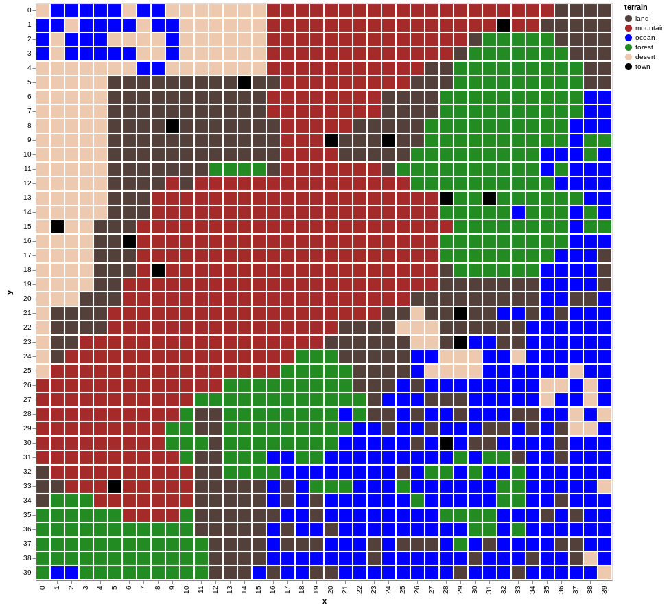

```python
world.add_features(all_towns)
#TODO: Update drawCities to support more terrain types
draw.drawCities(world.df_features)
```

```python
world.df_features[world.df_features['feature'].isna()==False]
```

| key | y | rainfall | x | key | elevation | terrain | feature |
| --- | --- | --- | --- | --- | --- | --- | --- |
| 32:1 | 1 | 26.0 | 32 | 32:1 | 22.0 | town | Artjaw |
| 14:5 | 5 | 2.0 | 14 | 14:5 | 17.0 | town | Ratgarden |
| 9:8 | 8 | 7.0 | 9 | 9:8 | 7.0 | town | Waterhollow |
| 20:9 | 9 | 7.0 | 20 | 20:9 | 27.0 | town | Snaketown |
| 24:9 | 9 | 14.0 | 24 | 24:9 | 13.0 | town | Camcrawl |
| 28:13 | 13 | 60.0 | 28 | 28:13 | 20.0 | town | Snakejaw |
| 31:13 | 13 | 87.0 | 31 | 31:13 | 8.0 | town | Starblade |
| 1:15 | 15 | 0.0 | 1 | 1:15 | 2.0 | town | Lilyvale |
| 6:16 | 16 | 11.0 | 6 | 6:16 | 20.0 | town | Solhail |
| 8:18 | 18 | 22.0 | 8 | 8:18 | 43.0 | town | Tearfellow |
| 29:21 | 21 | 4.0 | 29 | 29:21 | 5.0 | town | Doomtown |
| 29:23 | 23 | 2.0 | 29 | 29:23 | 1.0 | town | Artfold |
| 28:30 | 30 | 26.0 | 28 | 28:30 | 1.0 | town | Ravenmore |
| 5:33 | 33 | 40.0 | 5 | 5:33 | 34.0 | town | Ratblade |

# Nations

```python
#k is the actual k_means cluster object.
all_nations,k = nations.cluster_nations(world)
world.nations = all_nations

all_nations
```

```
{0: 'Gleamlair',
 1: 'Leafhaven',
 2: 'Fairmain',
 3: 'Fenhail',
 4: 'Spinfold',
 5: 'Lordshaven',
 6: 'Artrun',
 7: 'Flamemore'}
```

Standard Scikit-Learn stuff

```python
k
```

```
KMeans(algorithm='auto', copy_x=True, init='k-means++', max_iter=300,
       n_clusters=8, n_init=10, n_jobs=None, precompute_distances='auto',
       random_state=None, tol=0.0001, verbose=0)
```

```python
world.df_features = nations.predict_nations(k,world)
world.df_features.head(20)
```

| key | y | rainfall | x | key | elevation | terrain | feature | nation number | nation |
| --- | --- | --- | --- | --- | --- | --- | --- | --- | --- |
| 0:0 | 0 | 0.0 | 0 | 0:0 | 1.0 | desert | NaN | 7.0 | Flamemore |
| 1:0 | 0 | 0.0 | 1 | 1:0 | 0.0 | ocean | NaN | NaN | NaN |
| 2:0 | 0 | 0.0 | 2 | 2:0 | 0.0 | ocean | NaN | NaN | NaN |
| 3:0 | 0 | 0.0 | 3 | 3:0 | 0.0 | ocean | NaN | NaN | NaN |
| 4:0 | 0 | 0.0 | 4 | 4:0 | -1.0 | ocean | NaN | NaN | NaN |
| 5:0 | 0 | 0.0 | 5 | 5:0 | 0.0 | ocean | NaN | NaN | NaN |
| 6:0 | 0 | 0.0 | 6 | 6:0 | 1.0 | desert | NaN | 7.0 | Flamemore |
| 7:0 | 0 | 0.0 | 7 | 7:0 | 0.0 | ocean | NaN | NaN | NaN |
| 8:0 | 0 | 0.0 | 8 | 8:0 | 0.0 | ocean | NaN | NaN | NaN |
| 9:0 | 0 | 0.0 | 9 | 9:0 | 1.0 | desert | NaN | 7.0 | Flamemore |
| 10:0 | 0 | 0.0 | 10 | 10:0 | 5.0 | desert | NaN | 7.0 | Flamemore |
| 11:0 | 0 | 0.0 | 11 | 11:0 | 5.0 | desert | NaN | 7.0 | Flamemore |
| 12:0 | 0 | 0.0 | 12 | 12:0 | 7.0 | desert | NaN | 7.0 | Flamemore |
| 13:0 | 0 | 0.0 | 13 | 13:0 | 9.0 | desert | NaN | 7.0 | Flamemore |
| 14:0 | 0 | 0.0 | 14 | 14:0 | 14.0 | desert | NaN | 7.0 | Flamemore |
| 15:0 | 0 | 0.0 | 15 | 15:0 | 19.0 | desert | NaN | 7.0 | Flamemore |
| 16:0 | 0 | 0.0 | 16 | 16:0 | 25.0 | mountain | NaN | 7.0 | Flamemore |
| 17:0 | 0 | 0.0 | 17 | 17:0 | 26.0 | mountain | NaN | 7.0 | Flamemore |
| 18:0 | 0 | 0.0 | 18 | 18:0 | 31.0 | mountain | NaN | 7.0 | Flamemore |
| 19:0 | 0 | 0.0 | 19 | 19:0 | 37.0 | mountain | NaN | 1.0 | Leafhaven |

The age of conflict is next, so the starting fealty and diplomacy for each town is 1

```python
for t in all_towns:
    try:
        t.set_starting_fielty(world)
    except:
        continue

town = world.towns[1]
print(f"{town.name} is loyal to the nation of {town.nation}")
print(f"{town.diplomacy}")
```

```
Starblade is loyal to the nation of Spinfold
{'nation': 'Spinfold', 'national fealty': 1}
```

```python
#for each nation (n), appoint the most populus city (c) as it's capitol.
for n in np.unique(world.df_features['nation'].dropna()):
    cu = world.df_features[(world.df_features['nation']==n)& \
          (world.df_features['terrain']=='town')]['feature'].tolist()
    #getting the town objects
    ts = [t for t in all_towns if t.name in cu]
    #get population(p)
    p = [t.pop for t in ts]
    #getting the first town that has the max population, make that the capitol
    ts[np.argmax(p)].type='capitol'

world.towns
```

```
[capitol of Lilyvale: population: 5 location: [1,15] founded 0,
 capitol of Starblade: population: 6 location: [31,13] founded 1,
 capitol of Ratgarden: population: 5 location: [14,5] founded 1,
 capitol of Snaketown: population: 5 location: [20,9] founded 2,
 town of Tearfellow: population: 3 location: [8,18] founded 3,
 town of Camcrawl: population: 4 location: [24,9] founded 3,
 town of Snakejaw: population: 3 location: [28,13] founded 4,
 town of Waterhollow: population: 4 location: [9,8] founded 6,
 capitol of Doomtown: population: 3 location: [29,21] founded 6,
 capitol of Ravenmore: population: 2 location: [28,30] founded 8,
 town of Artfold: population: 2 location: [29,23] founded 8,
 capitol of Artjaw: population: 2 location: [32,1] founded 9,
 capitol of Ratblade: population: 1 location: [5,33] founded 9,
 town of Solhail: population: 1 location: [6,16] founded 9]
```

```python
world.nations = [nations.Nation(n,world,world.culture,people) for n in world.nations.values()]
world.nations
```

```
[Nation of Gleamlair,
 Nation of Leafhaven,
 Nation of Fairmain,
 Nation of Fenhail,
 Nation of Spinfold,
 Nation of Lordshaven,
 Nation of Artrun,
 Nation of Flamemore]
```

```python
world.nations[0].towns
```

```
[capitol of Ratblade: population: 1 location: [5,33] founded 9]
```

```python
world.nations[0].get_capitol().population
```

```
[Hekillus the Speaker of Ratblade, Prayen the Ruler of the nation of Gleamlair]
```

So the world has nations, nations have towns, and towns have people. Objects all nested together and easy to reference. A nation's capitol will always have two people: the ruler and the speaker. Larger cities will have extra peons.

```python
world.nations[0].get_capitol().population[0].get_person_data()
```

```
{'name': 'Hekillus',
 'role': 'Speaker of Ratblade',
 'loyalty': 0.5,
 'temperment': 0.49}
```

```python
world.df_features[world.df_features['feature'].isna()==False].sort_values(['nation'])
```

| key | y | rainfall | x | key | elevation | terrain | feature | nation number | nation |
| --- | --- | --- | --- | --- | --- | --- | --- | --- | --- |
| 28:30 | 30 | 26.0 | 28 | 28:30 | 1.0 | town | Ravenmore | 6.0 | Artrun |
| 29:21 | 21 | 4.0 | 29 | 29:21 | 5.0 | town | Doomtown | 2.0 | Fairmain |
| 29:23 | 23 | 2.0 | 29 | 29:23 | 1.0 | town | Artfold | 2.0 | Fairmain |
| 1:15 | 15 | 0.0 | 1 | 1:15 | 2.0 | town | Lilyvale | 3.0 | Fenhail |
| 6:16 | 16 | 11.0 | 6 | 6:16 | 20.0 | town | Solhail | 3.0 | Fenhail |
| 8:18 | 18 | 22.0 | 8 | 8:18 | 43.0 | town | Tearfellow | 3.0 | Fenhail |
| 14:5 | 5 | 2.0 | 14 | 14:5 | 17.0 | town | Ratgarden | 7.0 | Flamemore |
| 9:8 | 8 | 7.0 | 9 | 9:8 | 7.0 | town | Waterhollow | 7.0 | Flamemore |
| 5:33 | 33 | 40.0 | 5 | 5:33 | 34.0 | town | Ratblade | 0.0 | Gleamlair |
| 20:9 | 9 | 7.0 | 20 | 20:9 | 27.0 | town | Snaketown | 1.0 | Leafhaven |
| 24:9 | 9 | 14.0 | 24 | 24:9 | 13.0 | town | Camcrawl | 1.0 | Leafhaven |
| 32:1 | 1 | 26.0 | 32 | 32:1 | 22.0 | town | Artjaw | 5.0 | Lordshaven |
| 28:13 | 13 | 60.0 | 28 | 28:13 | 20.0 | town | Snakejaw | 4.0 | Spinfold |
| 31:13 | 13 | 87.0 | 31 | 31:13 | 8.0 | town | Starblade | 4.0 | Spinfold |

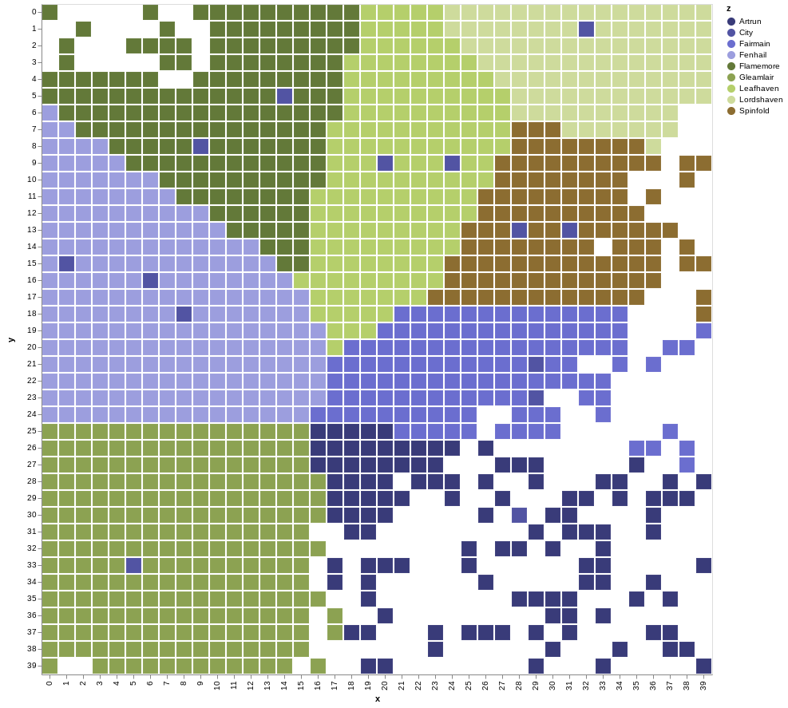

```python
draw.drawboarders(world.df_features)
```

# Saving the local copy

Saving a local copy of the pickled file for update. TODO: add function to save pickle in S3

```python
world.df_features.head(10)
```

| key | y | rainfall | x | key | elevation | terrain | feature | nation number | nation | z |
| --- | --- | --- | --- | --- | --- | --- | --- | --- | --- | --- |
| 0:0 | 0 | 0.0 | 0 | 0:0 | 1.0 | desert | NaN | 7.0 | Flamemore | Flamemore |
| 1:0 | 0 | 0.0 | 1 | 1:0 | 0.0 | ocean | NaN | NaN | NaN | NaN |
| 2:0 | 0 | 0.0 | 2 | 2:0 | 0.0 | ocean | NaN | NaN | NaN | NaN |
| 3:0 | 0 | 0.0 | 3 | 3:0 | 0.0 | ocean | NaN | NaN | NaN | NaN |
| 4:0 | 0 | 0.0 | 4 | 4:0 | -1.0 | ocean | NaN | NaN | NaN | NaN |
| 5:0 | 0 | 0.0 | 5 | 5:0 | 0.0 | ocean | NaN | NaN | NaN | NaN |
| 6:0 | 0 | 0.0 | 6 | 6:0 | 1.0 | desert | NaN | 7.0 | Flamemore | Flamemore |
| 7:0 | 0 | 0.0 | 7 | 7:0 | 0.0 | ocean | NaN | NaN | NaN | NaN |
| 8:0 | 0 | 0.0 | 8 | 8:0 | 0.0 | ocean | NaN | NaN | NaN | NaN |
| 9:0 | 0 | 0.0 | 9 | 9:0 | 1.0 | desert | NaN | 7.0 | Flamemore | Flamemore |

```python
with open('world_1.p', 'wb') as pickle_file:
    pickle.dump(world, pickle_file)
```